# 4. Preprocesamiento de los datos

En este notebook se realiza el estudio y preprocesamiento de las variables numéricas y categoricas. Se realizarán los siguientes pasos:

1. Análisis de cada variable con gráficos descriptivos
2. Para variables numéricas: correlaciones de Pearson y estudio de outliers.
3. Para variables categoricas: estudio de correlaciones con vCramer

## **Librerías**

```python
from matplotlib import pyplot as plt
from sklearn.impute import KNNImputer
from sklearn.model_selection import train_test_split
from funciones_fraud import *

import pandas as pd
import numpy as np
import seaborn as sns
import plotly.express as px
import scipy.stats as ss
import warnings
import math

warnings.filterwarnings('ignore')

pd.set_option('display.max_columns', 500)
pd.set_option('display.max_rows', 5000)
```

## **Lectura de datos del preprocesado inicial**

A continuación abriremos los datasets de train0 y test que hemos separado previamente en el notebook 1.

```python
path_folder = "./"
df_train = pd.read_csv(path_folder +"train0_data.csv", low_memory=False)
df_test = pd.read_csv(path_folder +"test_data.csv", low_memory=False)
print(df_train.shape, df_test.shape)
```

```
(800000, 32) (200000, 32)
```

```python
columnas_categoricas, columnas_continuas = categorizar_columnas(df_train)
```

```
Conteo de valores para 'payment_type':
payment_type
AB    296135
AA    206641
AC    201863
AD     95135
AE       226
Name: count, dtype: int64


Conteo de valores para 'employment_status':
employment_status
CA    584188
CB    110459
CF     35297
CC     30252
CD     21224
CE     18227
CG       353
Name: count, dtype: int64


Conteo de valores para 'housing_status':
housing_status
BC    297793
BB    209055
BA    135451
BE    135337
BD     20839
BF      1325
BG       200
Name: count, dtype: int64


Conteo de valores para 'source':
source
INTERNET    794336
TELEAPP       5664
Name: count, dtype: int64


Conteo de valores para 'device_os':
device_os
other        274058
linux        266078
windows      210902
macintosh     43160
x11            5802
Name: count, dtype: int64
```

## **Visualización descriptiva de los datos**

En esta parte realizaremos gráficos para observar como se comportan los diferentes atriburos teniendo en cuenta si son variables numéricas o categóricas.

```python
columnas_int_boxplot = ['credit_risk_score', 'bank_branch_count_8w', 'zip_count_4w', 'current_address_months_count', 'prev_address_months_count']
columnas_float64 = df_train.select_dtypes(include=['float64'])

numeric_columns = pd.concat([columnas_float64, df_train[columnas_int_boxplot]], axis=1)
int_columns_no_boxplot = [col for col in df_train.select_dtypes(include='int').columns if col not in columnas_int_boxplot]

float_columns = df_train.select_dtypes(include='float').columns
df_train[float_columns] = df_train[float_columns].round(2)

df_categoricas = df_train[columnas_categoricas + ['fraud_bool']]
df_numericas_enteros = df_train[int_columns_no_boxplot]
```

### **Visualización descriptiva de los atributos numéricos**

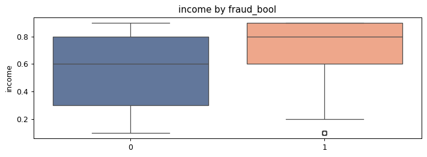

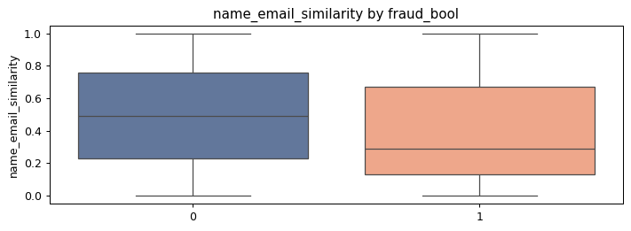

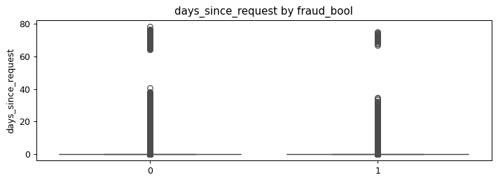

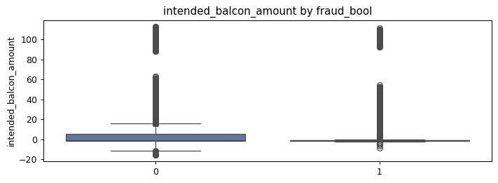

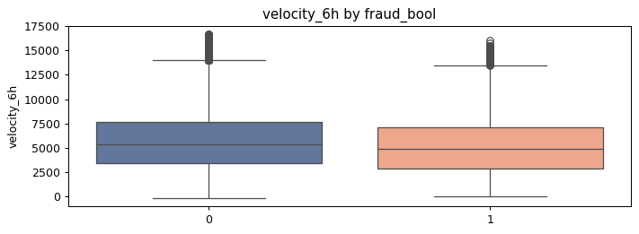

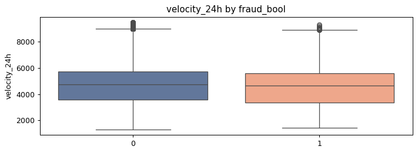

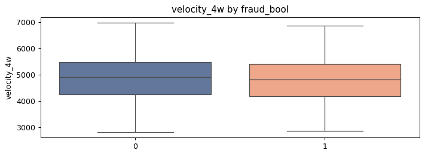

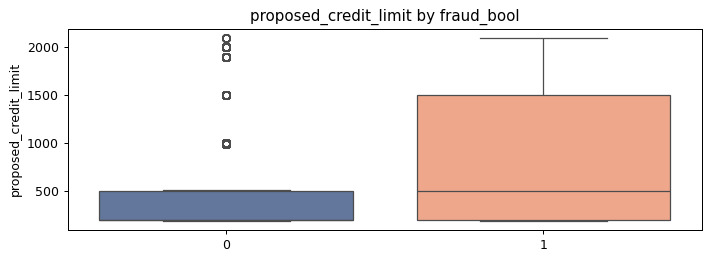

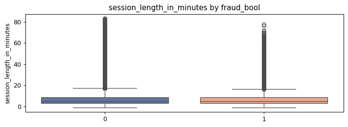

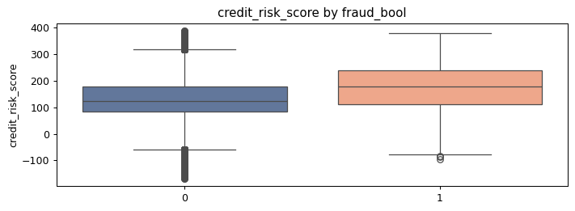

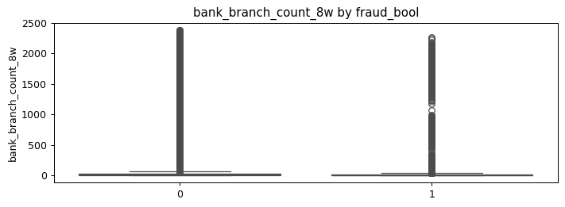

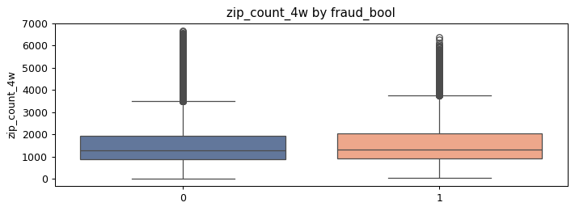

[2 more figures not shown]

```
CPU times: total: 24.6 s
Wall time: 25.2 s
```

```python
%%time
for col_name in numeric_columns:
    plot_numeric_feature(df_train, col_name, 'fraud_bool')
    plt.show()
```

Hemos graficado mediante boxplots, las variables numéricas de nuestro dataset. Estas son a las conclusiones que hemos llegado:

1. En primer lugar podemos observar la variable **income**, en ella, las personas fraudulentas tienden a tener unos ingresos anuales más elevados en comparación que las solicitantes no fraudulentos.
2. En **name_email_similarity** podemos observar que la mediana de los fraudulentos es bastante menor si la comparamos con los no fraudulentos. Esto puede significar que las personas fraudulentas suelen no presentar similitud entre su nombre y su correo electrónico.
3. La variable **days_since_request** podemos observar que la mayoría de los datos están concentrados en los días cercanos a 0, sin emabargo, existen gran cantidad de outliers que se distribuyen hasta incluso los 80 días. Esto se puede deber a un tema relacionado con la carga de trabajo o la estacionalidad, ya que hay meses en los que trabaja menos plantilla.
4. La variable **intended_balcon_amount**, es el importe inicial transferido. En el caso de los solicitantes no fraudulentos, es ligeramente más elevado en comparación con los que si son. En ambos casos podemos observar el gran número de outliers que se reparten en valores muy elevados.
5. Las siguientes serían **velocity_6h**,**velocity_24h** y **velocity_4w**, estas miden el número medio de solicitudes por hora en las últimas 6 horas, 24 horas y 4 semanas, respectivamente. Las analizamos a la vez ya que tienen un comportamiento muy similar. Podemos observar que los comportamientos de ambos clientes son muy parecidos. Una observación a destacar es que a medida que aumenta el tiempo hay menos outliers, quedándose el que mide hasta 4 semanas sin ningún outlier. Van disminuyendo los outliers a medida que se coge más rango temporal.
6. **proposed_credit_limit**, en esta variable podemos observar que hay gran diferencia entre los solicitantes fraudulentos y los que no. Podemos ver que los fraudulentos no están concentrados en un valor de crédito concreto sino que se encuentran más dispersos entre los valores menores a 500 hasta 1500. En cambio, los no fraudulentos se concentran en límites de crédito menores a 500.
7. La siguiente variable sería **session_length_in_minutes**, que mide los minutos que ha durado la solicitud del crédito. Se puede admirar que los comportamientos son muy similares para ambos solicitantes. Se concentran en valores menores de 10 minutos, pero existen gran cantidad de outliers que pueden llegar a tener solicitudes de hasta 80 minutos.
8. Después vendría **credit_risk_score** que evalua la puntuación interna que mide el riesgo de la solicitud de crédito. Se detecta un riesgo más elevado en los clientes fraudulentos. Sin embargo hay muchos outliers no fraudulentos que superan la puntuación de la amplia mayoría de los que si son. También los que no son fraudulentos tienen gran cantidad de outliers negativos, esto se debe a que son valores missing que han sido tratados. Si los comparamos con los otros clientes podemos observar que hay mayor cantidad en los que no llegan a ser fraudulentos.
9. Después vendría **bank_branch_count_8w**, mide el número de solicitudes que se han hecho en la misma sucursal en las últimas 8 semanas. Podemos observar que existen gran cantidad de outliers, pero que el boxplot se ve muy concentado en valores más cercanos al 0. Ambos comportamientos de los solicitantes son muy similares.
10. La variable **zip_count_4w**, número de solicitudes dentro del mismo código postal en las últimas 4 semanas, vemos que se comporta muy parecido en personas que son y que no son fraudulentas, no hay distinción.
11. Podemos observar que tenemos menos outliers menos concentrados, otro detalle a destacar es que se han aumentado las medianas tanto los fraudulentos como los que no. También vemos que el **current_address_months_count** son ligeramente mayores los valores de los solicitantes fraudulentos. Podemos afirmar que la mediana de los fraudulentos es mayor que los que no lo son.
12. En la siguiente variable **prev_addres_months_count**, podemos observar que tanto en solicitantes fraudulentos o no fraudulentos se concentran en valores menores a 50, a partir de ahí hasta el valor 400, existen gran cantidad de outliers. Podemos concluir que ambos perfiles tienen menos de 50 meses registrados en su vivienda anterior. Teniendo outliers de hasta 400 meses.

```
CPU times: total: 19.6 s
Wall time: 19.8 s
```

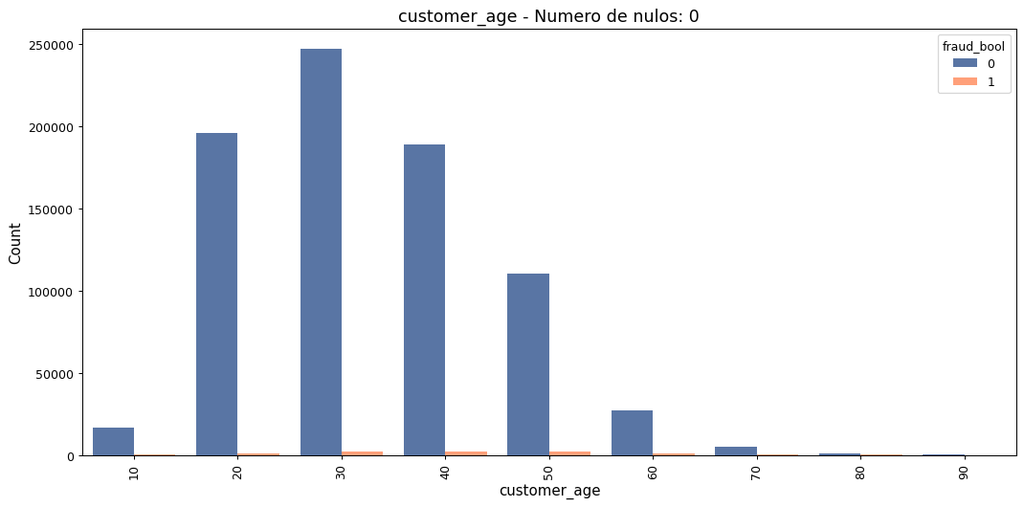

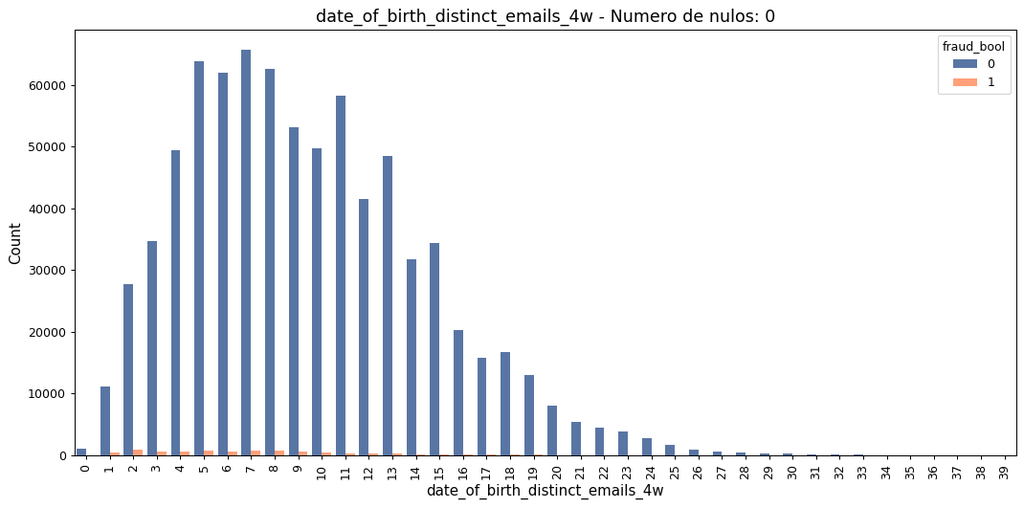

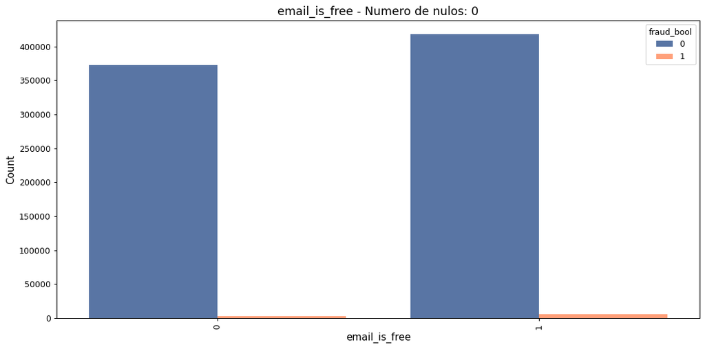

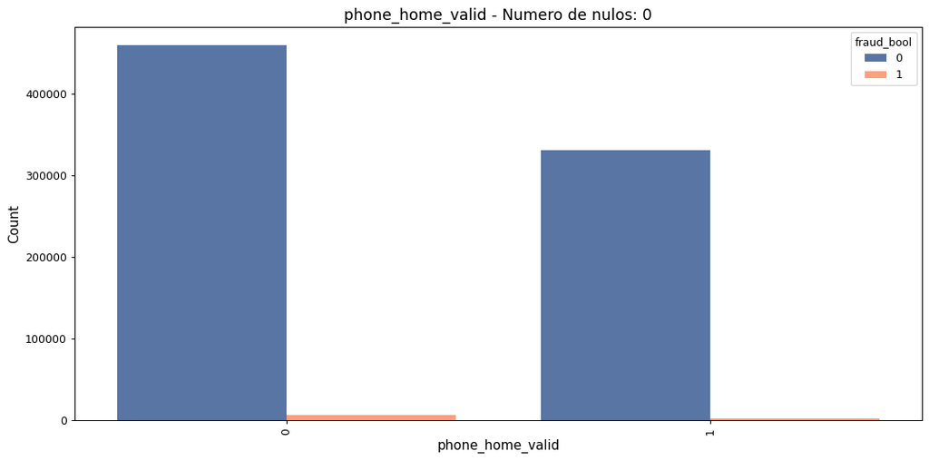

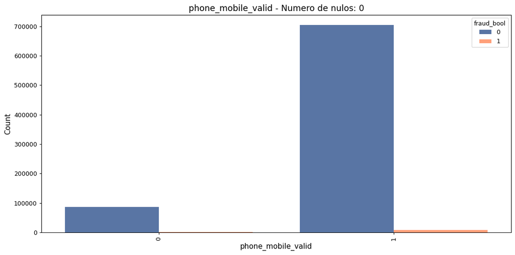

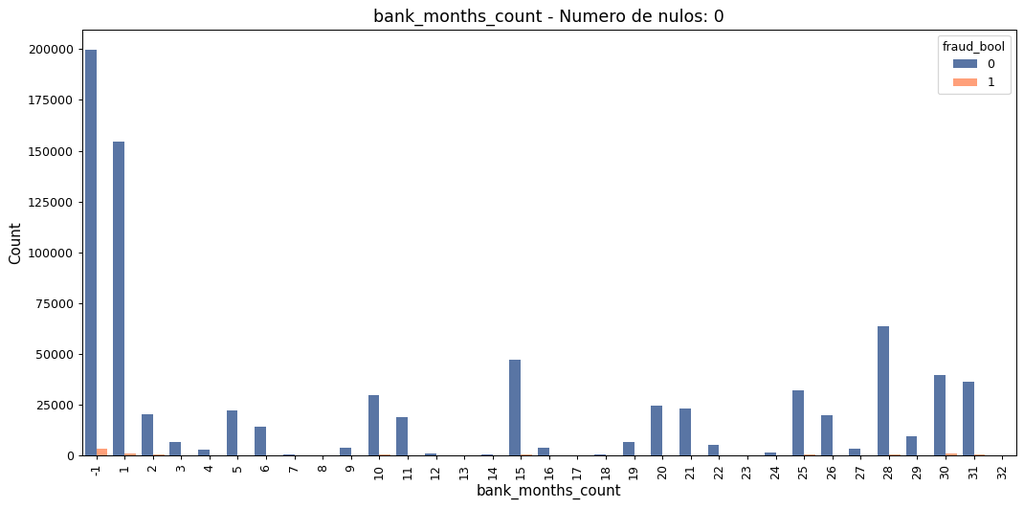

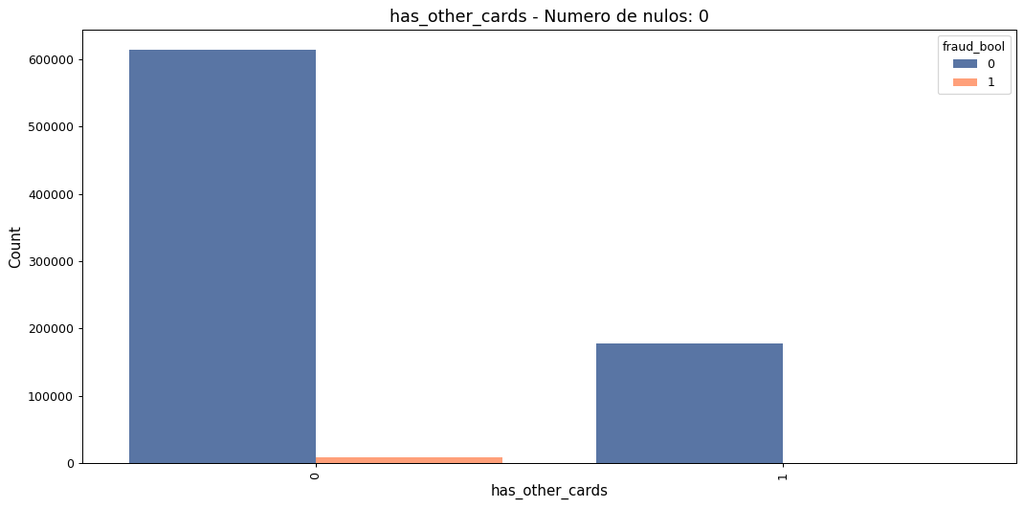

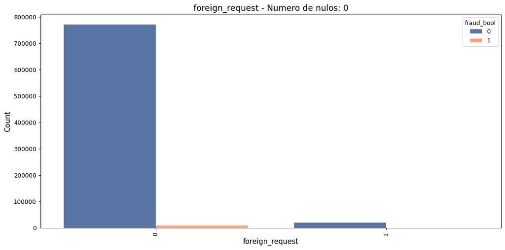

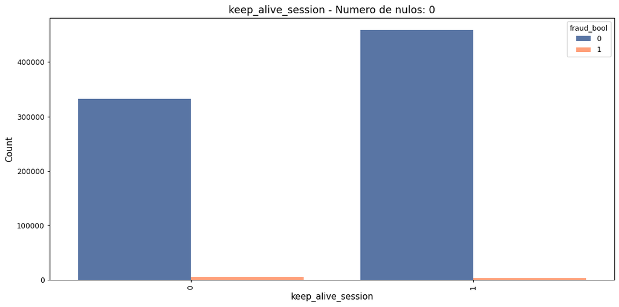

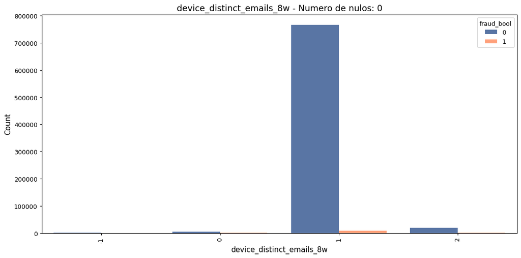

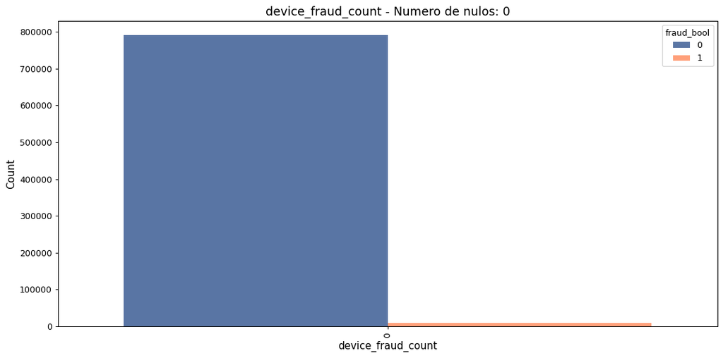

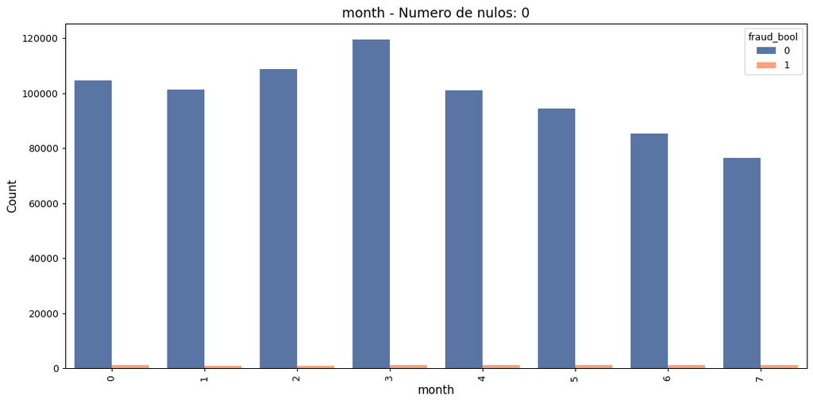

[1 more figures not shown]

```python
%%time
plot_numeric_int_feature(df_numericas_enteros, 'fraud_bool')
```

1. La variable que mide la edad del solicitante, **customer_age**, podemos observar que los no fraudulentos se reparten entre los 20 hasta los 50 años, luego hay outliers menores y mayores a esas edades. Los fraudulentos tienen la misma distribución desde los 20 años hasta los 50, teniendo unos pocos outliers de 60. Podemos observar que tienen comportamientos similares pero la distribución de los fraudulentos es la misma en cada rango de edad.
2. La siguiente, **date_of_birth_distinct_emails_4w**, vemos que los fraudulentos estan concentrados en la misma proporción desde un único correo electrónico hasta 13 en los que coincide la misma fecha de nacimiento en las últimas 4 semanas. A diferencia de los fraudulentos, los que no lo son, siguen una distribución normal, destacando 7 correos electrónicos.
3. Después, **email_is_free** muestra si el dominio del correo electrónico es privado o público. Consideramos que esta variable no es muy reveladora que que ambos perfiles mantienen una distribución muy similar.
4. **phone_home_valid** y **phone_mobile_valid** tienen comportamientos opuestos. Siendo los teléfonos fijos en su mayoría no válidos sin embargo los números de móviles tienden a ser la gran mayoría válidos. Con diferentes distribuciones pero ambos perfiles siguen la moda en ambas variables.
5. **bank_months_count** mide los meses que se ha tenido una cuenta anterior, los que no se tiene registro son valores -1, podemos observar gran cantidad de solitantes que no se sabe si han tenido una cuenta anterior. No observamos información que nos ayude o nos aporte.
6. **has_other_cards** vemos que ambos tipos de solicitantes no tienen otra tarjeta asociada.
7. **foreign_request** mide si se ha realizado la solicitud en un país distinto a la del banco, podemos observar que la mayoría se hacen el mismo país de origen del banco.
8. La siguiente, **keep_alive_session** mide si los clientes han seguido con la sesión abierta o la han cerrado. Los fraudulentos suelen cerrar y los no fraudulentos suelen dejarlo puesto.
9. Más tarde, viene **device_distinct_emails_8w**, mide el úmero de correos electrónicos distintos en el sitio web del banco desde el dispositivo utilizado en las últimas 8 semanas. Podemos observar que la categoría que más destaca es la 1. El valor -1 son los valores missing.
10. La penúltima es **device_fraud_count** Número de solicitudes fraudulentas con el mismo dispositivo utilizado, podemos observar que todos los registros están concentrados en la categoría 0. Esta variable se eliminará del dataset ya que no aporta información.
11. La última sería **month**, que nos indica en que mes se hizo la solicitud. Podemos observar que los clientes fraudulentos mantienen la misma distribución en los 8 meses. Podemos confirmar que no hay un mes de preferencia, a la hora de hacer solicitudes fraudulentas.

```
CPU times: total: 6.72 s
Wall time: 6.74 s
```

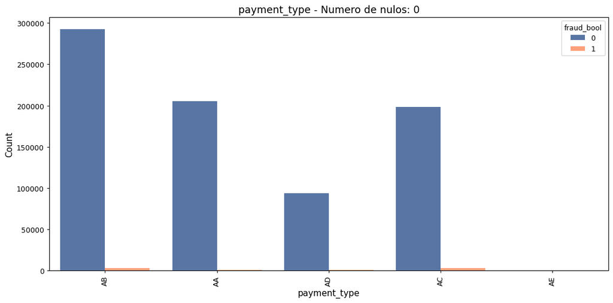

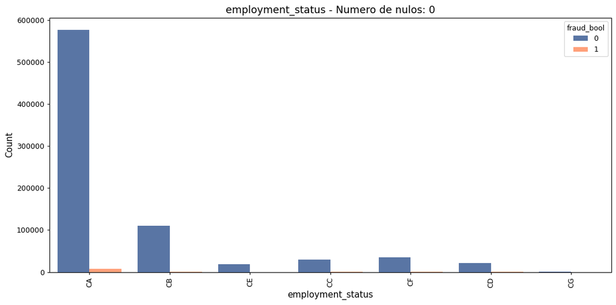

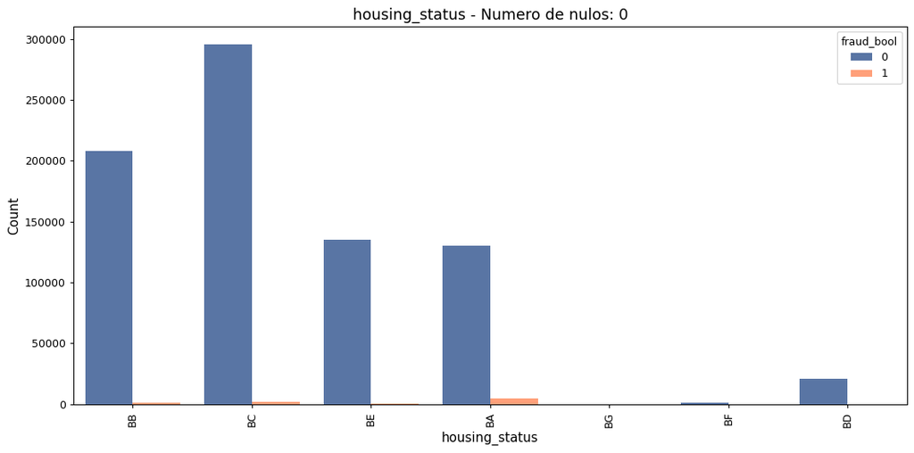

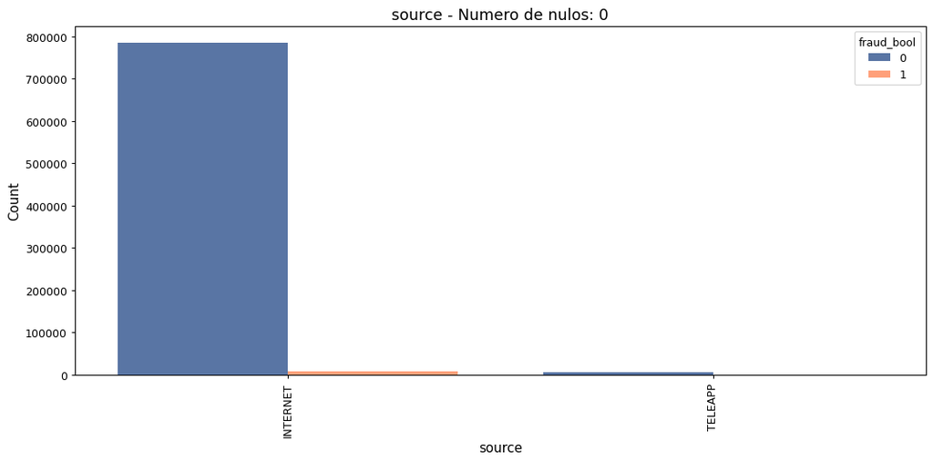

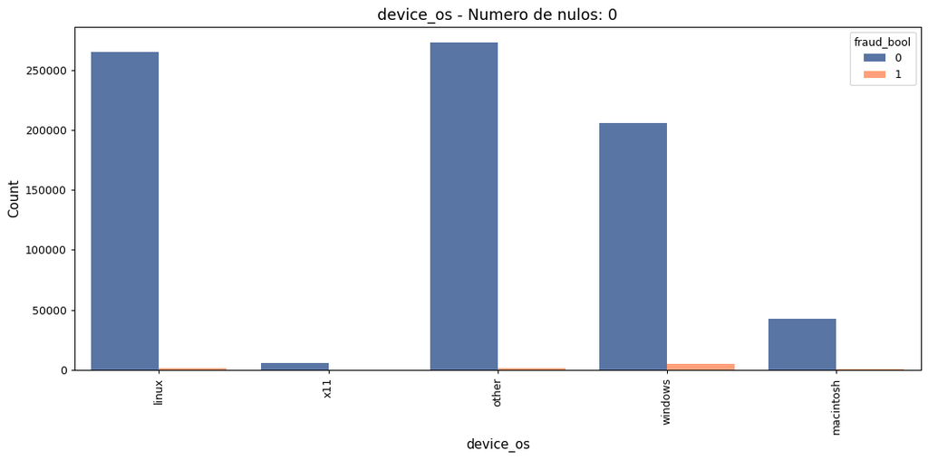

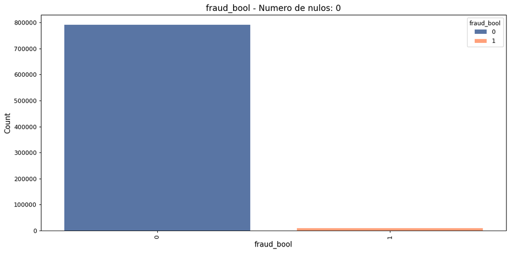

```python
%%time
plot_categorical_feature(df_categoricas, 'fraud_bool')
```

## **Tratamiento de las variables continuas**

```python
columnas_continuas
```

```
['income',
 'name_email_similarity',
 'prev_address_months_count',
 'current_address_months_count',
 'customer_age',
 'days_since_request',
 'intended_balcon_amount',
 'zip_count_4w',
 'velocity_6h',
 'velocity_24h',
 'velocity_4w',
 'bank_branch_count_8w',
 'date_of_birth_distinct_emails_4w',
 'credit_risk_score',
 'email_is_free',
 'phone_home_valid',
 'phone_mobile_valid',
 'bank_months_count',
 'has_other_cards',
 'proposed_credit_limit',
 'foreign_request',
 'session_length_in_minutes',
 'keep_alive_session',
 'device_distinct_emails_8w',
 'device_fraud_count',
 'month']
```

### **Tratamiento de outliers**

```python
outliers(df_train, columnas_continuas, target='fraud_bool', multiplier=3)
```

|  | variable | sum_outlier_values_custom | porcentaje_outlier_values | perc_fraud_1 | perc_fraud_0 |
| --- | --- | --- | --- | --- | --- |
| 0 | prev_address_months_count | 20230 | 0.025288 | 0.006574 | 0.993426 |
| 1 | current_address_months_count | 17181 | 0.021476 | 0.016122 | 0.983878 |
| 2 | customer_age | 6334 | 0.007917 | 0.041680 | 0.958320 |
| 3 | days_since_request | 14206 | 0.017756 | 0.011968 | 0.988032 |
| 4 | intended_balcon_amount | 15203 | 0.019004 | 0.009538 | 0.990462 |
| 5 | zip_count_4w | 12933 | 0.016166 | 0.009433 | 0.990567 |
| 6 | velocity_6h | 3452 | 0.004315 | 0.006373 | 0.993627 |
| 7 | velocity_24h | 430 | 0.000538 | 0.004651 | 0.995349 |
| 8 | bank_branch_count_8w | 32787 | 0.040984 | 0.010339 | 0.989661 |
| 9 | date_of_birth_distinct_emails_4w | 5007 | 0.006259 | 0.006191 | 0.993809 |
| 10 | credit_risk_score | 2916 | 0.003645 | 0.031207 | 0.968793 |
| 11 | proposed_credit_limit | 4927 | 0.006159 | 0.129085 | 0.870915 |
| 12 | foreign_request | 20253 | 0.025316 | 0.022120 | 0.977880 |
| 13 | session_length_in_minutes | 18840 | 0.023550 | 0.020382 | 0.979618 |
| 14 | device_distinct_emails_8w | 25477 | 0.031846 | 0.037210 | 0.962790 |

### **Correlaciones**

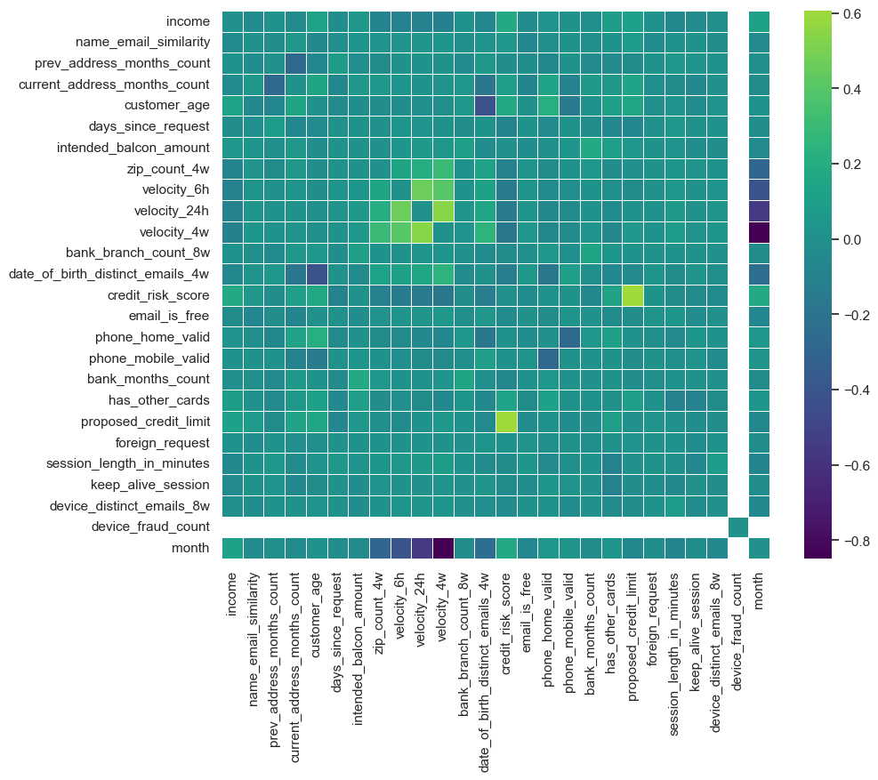

```python
matrix_corr= get_corr_matrix(dataset = df_train[columnas_continuas], metodo='pearson', size_figure=[10,8])
```

```python
show_lower_triangle_values(matrix_corr)
```

|  | Variable 1 | Variable 2 | Correlation |
| --- | --- | --- | --- |
| 286 | month | velocity_4w | -0.848363 |
| 184 | proposed_credit_limit | credit_risk_score | 0.606474 |
| 285 | month | velocity_24h | -0.549687 |
| 54 | velocity_4w | velocity_24h | 0.539256 |
| 44 | velocity_24h | velocity_6h | 0.464763 |
| 70 | date_of_birth_distinct_emails_4w | customer_age | -0.420048 |
| 284 | month | velocity_6h | -0.409050 |
| 53 | velocity_4w | velocity_6h | 0.400443 |
| 52 | velocity_4w | zip_count_4w | 0.303002 |
| 283 | month | zip_count_4w | -0.287286 |
| 5 | current_address_months_count | prev_address_months_count | -0.272168 |
| 135 | phone_mobile_valid | phone_home_valid | -0.271906 |
| 288 | month | date_of_birth_distinct_emails_4w | -0.245372 |
| 76 | date_of_birth_distinct_emails_4w | velocity_4w | 0.243060 |
| 109 | phone_home_valid | customer_age | 0.212947 |
| 43 | velocity_24h | zip_count_4w | 0.201405 |
| 142 | bank_months_count | intended_balcon_amount | 0.178979 |
| 289 | month | credit_risk_score | 0.175719 |
| 69 | date_of_birth_distinct_emails_4w | current_address_months_count | -0.174680 |
| 78 | credit_risk_score | income | 0.171751 |
| 88 | credit_risk_score | velocity_4w | -0.168133 |
| 82 | credit_risk_score | customer_age | 0.166828 |
| 117 | phone_home_valid | date_of_birth_distinct_emails_4w | -0.166558 |
| 75 | date_of_birth_distinct_emails_4w | velocity_24h | 0.156023 |
| 175 | proposed_credit_limit | customer_age | 0.149379 |
| 124 | phone_mobile_valid | customer_age | -0.147154 |
| 87 | credit_risk_score | velocity_24h | -0.146782 |
| 86 | credit_risk_score | velocity_6h | -0.144899 |
| 9 | customer_age | current_address_months_count | 0.143553 |
| 147 | bank_months_count | bank_branch_count_8w | 0.142975 |

[output cut: 270 more lines]

La correlación cuantifica la relación lineal entre dos variables, oscilando entre -1 y 1.

## **Tratamiento de las variables categoricas**

```python
columnas_categoricas
```

```
['payment_type', 'employment_status', 'housing_status', 'source', 'device_os']
```

### **Correlaciones**

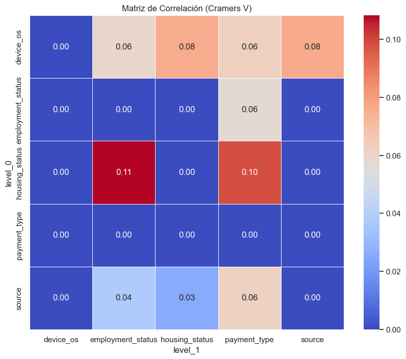

```python
cramer_matrix(df_train, columnas_categoricas)
```

```python
correlation_table = table_cramer_matrix(df_train, columnas_categoricas)

correlation_table
```

|  | Variable1 | Variable2 | Cramers_V |
| --- | --- | --- | --- |
| 11 | housing_status | employment_status | 0.108277 |
| 7 | employment_status | housing_status | 0.108277 |
| 10 | housing_status | payment_type | 0.098428 |
| 2 | payment_type | housing_status | 0.098428 |
| 19 | source | device_os | 0.076247 |
| 23 | device_os | source | 0.076247 |
| 22 | device_os | housing_status | 0.076127 |
| 14 | housing_status | device_os | 0.076127 |
| 20 | device_os | payment_type | 0.062584 |
| 4 | payment_type | device_os | 0.062584 |
| 15 | source | payment_type | 0.062095 |
| 3 | payment_type | source | 0.062095 |
| 21 | device_os | employment_status | 0.059037 |
| 9 | employment_status | device_os | 0.059037 |
| 1 | payment_type | employment_status | 0.057373 |
| 5 | employment_status | payment_type | 0.057373 |
| 8 | employment_status | source | 0.038059 |
| 16 | source | employment_status | 0.038059 |
| 13 | housing_status | source | 0.025481 |
| 17 | source | housing_status | 0.025481 |
| 0 | payment_type | payment_type | 0.000000 |
| 12 | housing_status | housing_status | 0.000000 |
| 18 | source | source | 0.000000 |
| 6 | employment_status | employment_status | 0.000000 |
| 24 | device_os | device_os | 0.000000 |

La matriz de correlación de Cramers_v es una matriz cuadrada que no sigue una estructura triangular por naturaleza. Su propósito es mostrar las asociaciones entre todas las combinaciones posibles de categorías de dos variables categóricas. Cada entrada en la matriz representa la fuerza de la asociación entre dos categorías específicas.

Moderada Asociación Positiva:

1. En el caso de "source" y "device_os" (Cramers_v = 0.07)
2. La relación entre "housing_status" y "device_os" destaca con un Cramers_v de 0.07.